# PML_Project_Writeup

Harsha Sattiraju

Friday, May 22, 2015

### 1 - Executive Summary

The goal of this project is to predict the manner in which 6 participants did an exercise. This is the “classe” variable in the training set. The rationale for the chosen predictors, why a specific model is chosen over the others, how the model is built, how was the model cross-validated and estimation of out of sample errors are documented.

#### 2-a: Load a session.

A session where all the required objects have already been pre-created(&tested) using the exact code shown throughout this document below is loaded. This is in the interest of saving time/avoid long run-time associated with running R-mark-down file and creating objects afresh on the fly.

```r
load("~/Work_Docs/DataScience/MachineLearning/pmlassignreqobj.RData")
```

#### 2-b: Download the data & load into R.

```r
fileurl<-"https://d396qusza40orc.cloudfront.net/predmachlearn/pml-training.csv"
download.file(fileurl, "pml-training.csv")
pmltraindat <- read.csv("pml-training.csv", header=T)
fileurl<-"https://d396qusza40orc.cloudfront.net/predmachlearn/pml-testing.csv"
download.file(fileurl, "pml-testing.csv")
pmltestdat<-read.csv("pml-testing.csv", header=T)
```

#### 3 - Load necessary libraries & set the seed.

```r
library(caret)
```

```r
library(ggplot2)
library(rattle)
library(ggplot2)
set.seed=300
```

#### 4 - Steps & Rationale in detection of the most sensitive predictors from the training set.

1 - Initially, built a model using one of the machine learning algorithms from caret library such as trees (rpart) or random forests (rf) with the provided training data. The idea is to use varImp function to get a rough estimate of what are the top 15-20 important predictors.

2 - Explored data i.e viewing the data to just get an idea if trends could be spotted. (scatter plots & manual inspection)

3 - Read the paper: http://groupware.les.inf.puc-rio.br/public/papers/2013.Velloso.QAR-WLE.pdf

4 - Based on 1, 2 & 3 above, concluded that the important parameters are:

a - 6 features for the Euler Angles: Roll, Pitch & Yaw - min, max, avg, variance, standard-deviation & amplitude.

b - Additionally variance of accelerometer for the arm, forearm, dumbbell & belt i.e total predictors: 3*6*4+4=76.

c - These were considered for each new window.

d - Used several algorithms: Trees(rpart), Bagging(treebag), Boosting(gbm), Native Bayes(nb) & Random Forests(rf).

e - Used several cross-validation(CV) methods: Data-Split, K-fold(k=10), Repeated K-fold(k=10 & repeat=10) & Leave-One-Out-CV(LOOCV).

f- Out of all combinations of PML algorithms & CV methods, found that Random Forests with Repeated K-fold CV was the best combination & able to acheive ~80% out-of-sample accuracy. Equally close was Boosting either with data-split or LOOCV.

5 - However, after looking at the 20 test-cases(as part of course project: Submission), the min/max/std-dev/avg/var/amp predictors were not available in the 20 rows. So, changed the strategy to use the primary predictors from which these 6 statistics were calculated.

a - So, the chosen predictors = 52:

i - Euler Angles: Roll, Pitch & Yaw for each sensor = 3*4=12

ii - Accelerometer, Gyrometer & Magnetometer’s readings on X, Y & Z axes for each sensor = 3*3*4=36

iii - Total Acceleration for all 4 sensors = 4

```r
modFitrpartallpred<-train(classe~., method="rpart", data=pmltraindat)
varImp(modFitrpartallpred)
```

```r
confusionMatrixboostds$overall
```

```
##       Accuracy          Kappa  AccuracyLower  AccuracyUpper   AccuracyNull
##   7.934783e-01   7.392990e-01   6.964302e-01   8.708400e-01   2.608696e-01
## AccuracyPValue  McnemarPValue
##   2.018085e-26            NaN
```

```r
confusionMatrixboostrp10fcv$overall
```

```
##       Accuracy          Kappa  AccuracyLower  AccuracyUpper   AccuracyNull
##   7.717391e-01   7.118138e-01   6.724896e-01   8.528072e-01   2.608696e-01
## AccuracyPValue  McnemarPValue
##   2.054951e-24            NaN
```

```r
confusionMatrixboostloocv$overall
```

```
##       Accuracy          Kappa  AccuracyLower  AccuracyUpper   AccuracyNull
##   7.934783e-01   7.392212e-01   6.964302e-01   8.708400e-01   2.608696e-01
## AccuracyPValue  McnemarPValue
##   2.018085e-26            NaN
```

```r
confusionMatrixrfds$overall
```

```
##       Accuracy          Kappa  AccuracyLower  AccuracyUpper   AccuracyNull
##   7.717391e-01   7.125000e-01   6.724896e-01   8.528072e-01   2.608696e-01
## AccuracyPValue  McnemarPValue
##   2.054951e-24            NaN
```

```r
confusionMatrixrfloocv$overall
```

```
##       Accuracy          Kappa  AccuracyLower  AccuracyUpper   AccuracyNull
##   7.717391e-01   7.125000e-01   6.724896e-01   8.528072e-01   2.608696e-01
## AccuracyPValue  McnemarPValue
##   2.054951e-24            NaN
```

```r
confusionMatrixrfrp10fcv$overall
```

```
##       Accuracy          Kappa  AccuracyLower  AccuracyUpper   AccuracyNull
##   7.934783e-01   7.400743e-01   6.964302e-01   8.708400e-01   2.608696e-01
## AccuracyPValue  McnemarPValue
##   2.018085e-26            NaN
```

```r
confusionMatrixrpartds$overall
```

```
##       Accuracy          Kappa  AccuracyLower  AccuracyUpper   AccuracyNull
##   6.847826e-01   6.003595e-01   5.795744e-01   7.777114e-01   2.608696e-01
## AccuracyPValue  McnemarPValue
##   2.256853e-17            NaN
```

```r
confusionMatrixbagrp10fcv$overall
```

```
##       Accuracy          Kappa  AccuracyLower  AccuracyUpper   AccuracyNull
##   7.934783e-01   7.404217e-01   6.964302e-01   8.708400e-01   2.608696e-01
## AccuracyPValue  McnemarPValue
##   2.018085e-26            NaN
```

```r
confusionMatrixnbrp10fcv$overall
```

```
##       Accuracy          Kappa  AccuracyLower  AccuracyUpper   AccuracyNull
##   6.521739e-01   5.609902e-01   5.457369e-01   7.485145e-01   2.608696e-01
## AccuracyPValue  McnemarPValue
##   4.234508e-15   1.887460e-01
```

#### 6 - Modeling using the final chosen/required predictors: Sub-set data containing the 52 important features (as described in 4-5) plus the “classe” variable column. And clean-up the data.

```r
rmcolnum<-c(grep("^kurtosis", colnames(pmldatclean)), grep("^skewness", colnames(pmldatclean)),  grep("^min", colnames(pmldatclean)), grep("^max", colnames(pmldatclean)), grep("^stddev", colnames(pmldatclean)), grep("^amp", colnames(pmldatclean)), grep("^var", colnames(pmldatclean)), grep("^avg", colnames(pmldatclean)))
rmcolnum<-c(1:7, rmcolnum1)
realdat<-pmldatclean[,-rmcolnum1]
```

#### 7 - Modeling using the final chosen/required predictors: Build a model using Trees(rpart), Boosting(gbm), Bagging(treebag) & Naive Bayes(nb) PMLs in the caret library. Validate out-of-sample error using CV methods. Please see RMD file for the code pertaining to all the algorithms considered.

```r
intrainreal<-createDataPartition(y=realdat$classe, p=0.7, list=FALSE)
trainingreal<-realdat[intrainreal,]
testingreal<-realdat[-intrainreal,]
```

```r
modFibagrealdatds<-train(classe~., method="treebag", data=trainingreal)
varImpbagrealdatds<-varImp(modFitbagtestdatds)
tabbagrealdatds<-table(predict(modFitbagrealdatds, testingreal), testingreal$classe)
confusionMatrixbagrealdatds<-confusionMatrix(tabbagrealdatds)
```

```r
confusionMatrixrpartrealdatds$overall
```

```
##       Accuracy          Kappa  AccuracyLower  AccuracyUpper   AccuracyNull
##   4.941376e-01   3.387132e-01   4.812846e-01   5.069965e-01   2.844520e-01
## AccuracyPValue  McnemarPValue
##  1.403996e-251            NaN
```

```r
confusionMatrixnbrealdatds$overall
```

```
##       Accuracy          Kappa  AccuracyLower  AccuracyUpper   AccuracyNull
##   7.403568e-01   6.671611e-01   7.289528e-01   7.515222e-01   2.844520e-01
## AccuracyPValue  McnemarPValue
##   0.000000e+00  2.497513e-122
```

```r
confusionMatrixboostrealdatrp10fcv$overall
```

```
##       Accuracy          Kappa  AccuracyLower  AccuracyUpper   AccuracyNull
##      0.9617672      0.9516254      0.9565487      0.9665213      0.2844520
## AccuracyPValue  McnemarPValue
##      0.0000000            NaN
```

```r
confusionMatrixboostrealdatds$overall
```

```
##       Accuracy          Kappa  AccuracyLower  AccuracyUpper   AccuracyNull
##   9.619371e-01   9.518394e-01   9.567290e-01   9.666806e-01   2.844520e-01
## AccuracyPValue  McnemarPValue
##   0.000000e+00   1.842568e-06
```

```r
confusionMatrixbagrealdatds$overall
```

```
##       Accuracy          Kappa  AccuracyLower  AccuracyUpper   AccuracyNull
##     0.98198811     0.97721206     0.97825636     0.98523038     0.28445200
## AccuracyPValue  McnemarPValue
##     0.00000000     0.04545935
```

```r
varImp(modFitbagrealdatds)
```

```
## treebag variable importance
##
##   only 20 most important variables shown (out of 52)
##
##                   Overall
## roll_belt          100.00
## yaw_belt            89.71
## pitch_belt          81.05
## pitch_forearm       76.34
## magnet_dumbbell_z   64.97
## roll_forearm        63.87
## magnet_dumbbell_y   61.75
## accel_dumbbell_y    51.95
## roll_dumbbell       49.00
## accel_belt_z        40.10
## magnet_belt_y       36.75
## magnet_belt_z       35.06
## yaw_arm             33.25
## magnet_dumbbell_x   31.66
## accel_dumbbell_z    30.12
## accel_forearm_x     28.59
## magnet_forearm_z    26.79
## gyros_belt_z        26.77
## total_accel_belt    24.82
## magnet_belt_x       23.15
```

```r
tabbagrealdatds
```

```
##
##        A    B    C    D    E
##   A 1663   19    4    1    0
##   B    5 1096   11    5    4
##   C    5   16 1007   11    3
##   D    0    5    4  944    6
##   E    1    3    0    3 1069
```

```r
confusionMatrixbagrealdatds$overall
```

```
##       Accuracy          Kappa  AccuracyLower  AccuracyUpper   AccuracyNull
##     0.98198811     0.97721206     0.97825636     0.98523038     0.28445200
## AccuracyPValue  McnemarPValue
##     0.00000000     0.04545935
```

#### 8 - Observations & Conclusions:

1 - Based on fitting models (PML algorithms) to the “classe” quality variable using a - the experimental predictors(min/max/avg/std-dev/var/amp) & b - final/chosen predictors & looking at out-of-sample accuracy using the training & testing data (created out of pml-training.csv data-set):

b - Random Forests, Bagging & Boosting seem to be better models in the caret library.

##### b - Cross-validation Method used: Data-Splitting. (over Repeated K-fold CV due to shorter run-time & near equal accuracy)

#### 9 - Plots for the chosen model: Bagging (treebag) with data-splitting CV.

1 - Plot of the 4 most important predictors using Bagging: treebag PML. Colored based on the predicted class.

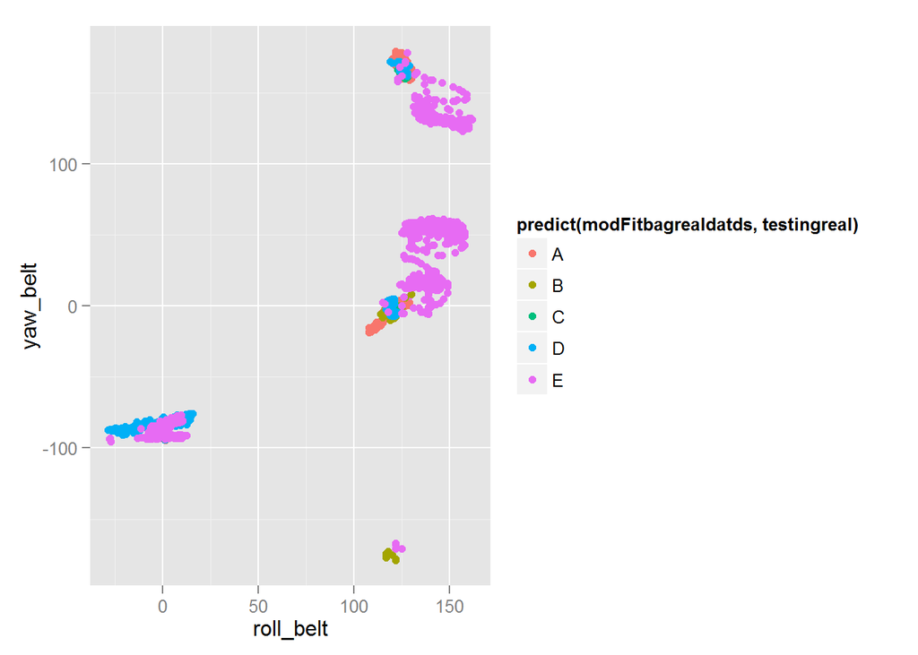

```r
qplot(roll_belt, yaw_belt, colour=predict(modFitbagrealdatds, testingreal), data=testingreal)
```

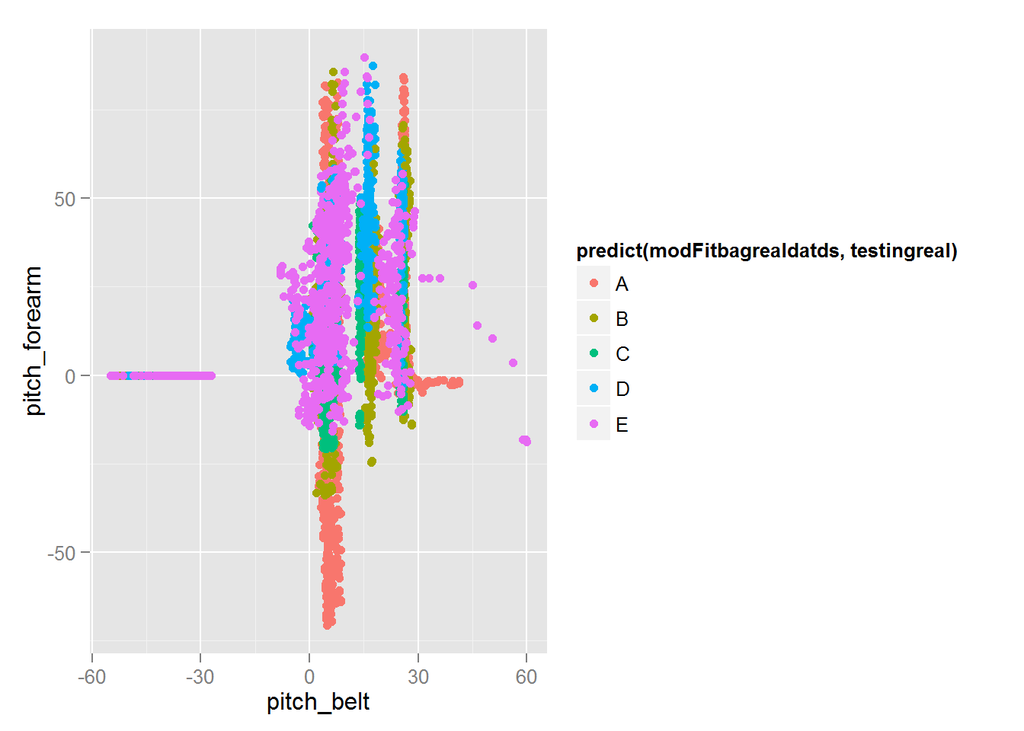

```r
qplot(pitch_belt, pitch_forearm, colour=predict(modFitbagrealdatds, testingreal), data=testingreal)
```

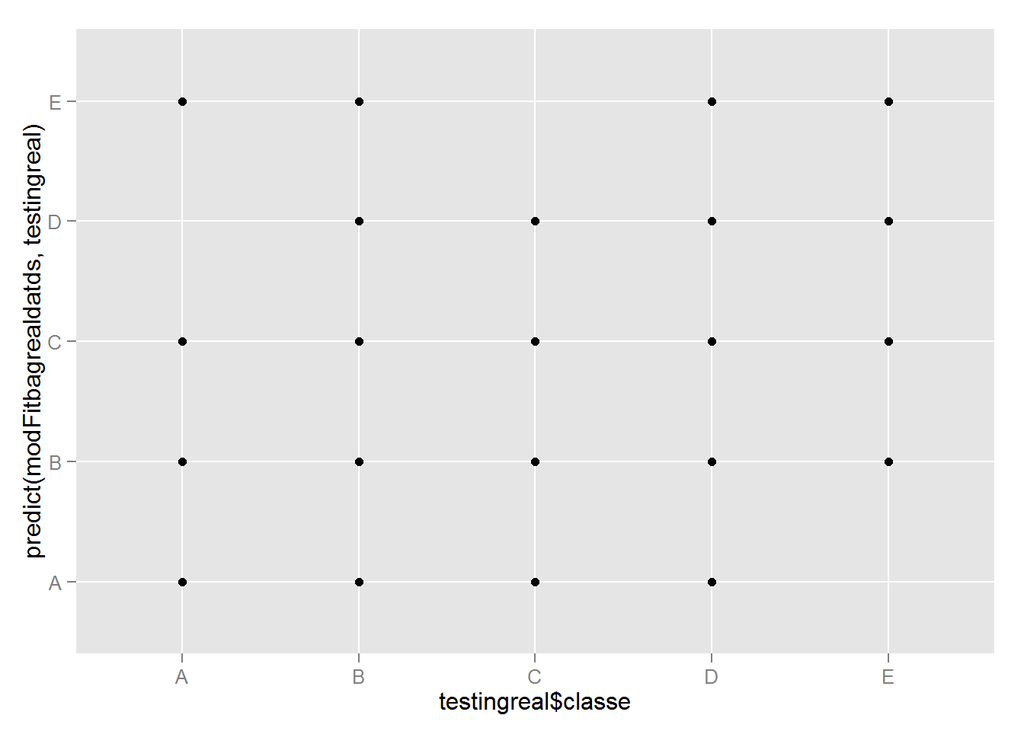

```r
qplot(testingreal$classe, predict(modFitbagrealdatds, testingreal), data=testingreal)
```

#### APPENDIX

1 - Modeling using min/max/var/std.dev/amp/avg predictors: Sub-set data containing the 76 important features (as described above) plus the “classe” variable column. And clean-up the data. Please see RMD file for the code.

2 - Modeling using min/max/var/std.dev/amp/avg predictors: Build & compare models using various PML algorithms in the caret library. Validate out-of-sample error using various CV methods. Please see RMD file for the code.